# QA of ODA indicator data

Emma Wood

25/07/2022

**Run date and time: 2022-09-22 16:24:41**

## Introduction

Most of the ODA indicators use the same source: [Statistics on International Development (SID) Final UK Aid Spend](https://www.gov.uk/government/statistics/statistics-on-international-development-final-uk-aid-spend-2020). This code has not been tested on the provisional data set, only the final spend.

It therefore makes sense to use automation to update these all at the same time, even though most of them are very straightforward.

This file records which indicators were run, shows which indicators failed (if any), and shows how the new data compare to the live data on charts.

Please check the source data for any footnotes.

## Configurations

The input filepaths used for this output are:

- ODA new data: **D:/coding_repos/sdg_data_updates/ODA/Example_Input/dataunderSID-Final2020_example.csv**
- ODA archived data: **D:/coding_repos/sdg_data_updates/ODA/Example_Input/data-underlying-sid-2017_example.csv**
- Exchange rates: **D:/coding_repos/sdg_data_updates/ODA/Example_Input/Exchange-rates_example.xlsx**
- Deflators: **D:/coding_repos/sdg_data_updates/ODA/Example_Input/Deflators-base-2020_example.xlsx**
- GNI url (for 1-a-1) **https://stats.oecd.org/restsdmx/sdmx.ashx/GetData/TABLE1/12+12.1.1.1140+1160.N/all?startTime=2009&endTime=2022**

The following indicators were included in the run:  
**1-a-1, 2-a-2, 3-b-2, 4-b-1, 6-a-1, 7-a-1, 8-a-1, 9-a-1, 17-9-1, 17-19-1**. See the next section to see if they all ran successfully.

The outputs are saved in: **D:/coding_repos/sdg_data_updates/ODA/Example_Output**

## Basic checks

```
## [1] "All scripts ran successfully"
```

## Differences between live data and new data

Please check the plots below for any differences between the live data (which is pulled in from the master branch of the sdg-data github repo) and the new data.

New data will appear over the top of currently live data.

Note that plots for constant USD show differences due to changes in the deflator values (where the base year has changed). Because of this, data for **all years** must be copied over to the indicator file.

It is sometimes hard to see where new numbers don’t match live numbers especially if there are lots of disaggregations. The tables below the plots show all instances where the old values do not match the new values. Each table is sorted so the largest absolute differences appear first, but can be sorted and filtered in other ways using the arrows at the top. As we expect changes in USD but not GBP, it is worth filtering for GBP.

### 1-a-1

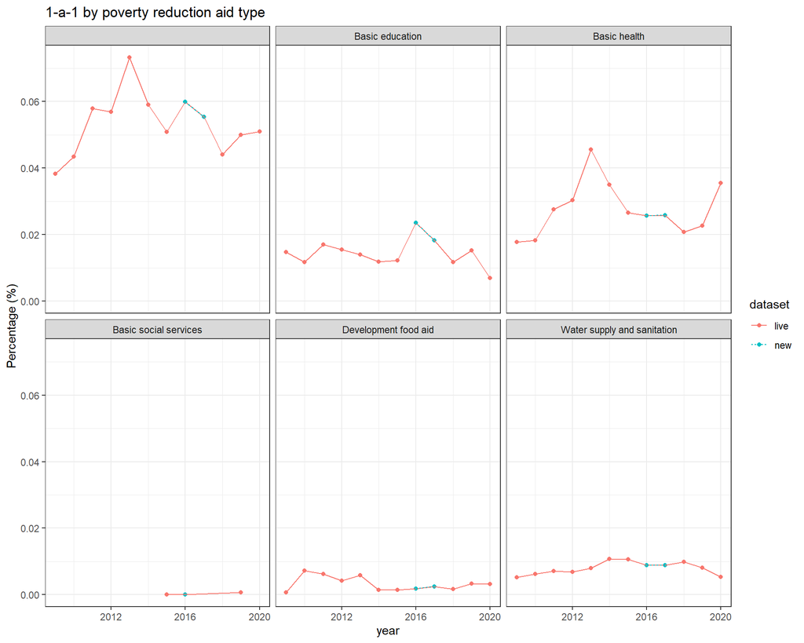

| year | poverty_reduction_aid_type | units | live | new | difference |
| --- | --- | --- | --- | --- | --- |
| 2017 |  | Percentage (%) | 0.055393495 | 0.0553934944964683 | -5.03531702444882e-10 |
| 2016 | Basic education | Percentage (%) | 0.023503947 | 0.0235039465451528 | -4.54847173814166e-10 |
| 2017 | Water supply and sanitation | Percentage (%) | 0.008798225 | 0.00879822538160336 | 3.81603360022353e-10 |
| 2017 | Basic health | Percentage (%) | 0.025875547 | 0.0258755466800632 | -3.1993676111175e-10 |
| 2016 | Basic social services | Percentage (%) | 2.62e-07 | 2.61683134943734e-07 | -3.1686505626623e-10 |
| 2017 | Basic education | Percentage (%) | 0.018304345 | 0.0183043452973232 | 2.97323221598589e-10 |
| 2016 | Basic health | Percentage (%) | 0.025673544 | 0.0256735437324251 | -2.67574937901083e-10 |
| 2016 | Water supply and sanitation | Percentage (%) | 0.008898125 | 0.00889812524460798 | 2.44607983174161e-10 |
| 2016 |  | Percentage (%) | 0.059928161 | 0.0599281611966311 | 1.96631093352106e-10 |
| 2017 | Development food aid | Percentage (%) | 0.002415377 | 0.00241537713747847 | 1.37478473050123e-10 |

[output cut: 1 more lines]

### 2-a-2

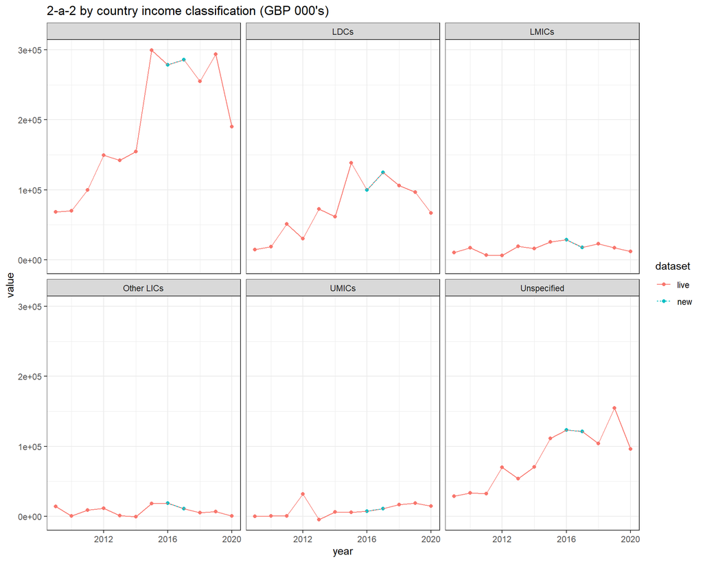

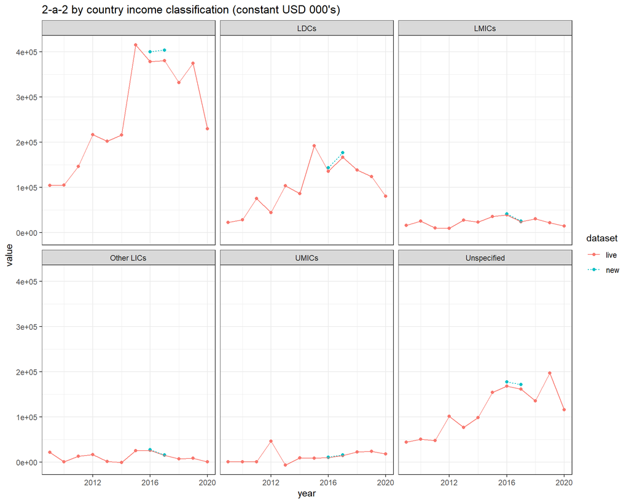

| year | country_income_classification | units | live | new | difference |
| --- | --- | --- | --- | --- | --- |
| 2017 |  | Constant USD, thousands | 380837.801846178 | 403865.618756602 | 23027.8169104238 |
| 2016 |  | Constant USD, thousands | 378003.333511204 | 400358.459979212 | 22355.1264680076 |
| 2017 | LDCs | Constant USD, thousands | 166327.581744026 | 176384.779534882 | 10057.1977908558 |
| 2016 | Unspecified | Constant USD, thousands | 167758.396741651 | 177679.633323178 | 9921.23658152678 |
| 2017 | Unspecified | Constant USD, thousands | 161653.258246958 | 171427.817433747 | 9774.55918678871 |
| 2016 | LDCs | Constant USD, thousands | 135402.455634664 | 143410.159604445 | 8007.703969781 |
| 2016 | LMICs | Constant USD, thousands | 38738.3164360864 | 41029.3013784975 | 2290.98494241106 |
| 2016 | Other LICs | Constant USD, thousands | 25888.1920147112 | 27419.2202255964 | 1531.02821088521 |
| 2017 | LMICs | Constant USD, thousands | 23529.241736998 | 24951.9657097884 | 1422.72397279038 |
| 2017 | Other LICs | Constant USD, thousands | 14753.9074243771 | 15646.0202268956 | 892.112802518568 |

[output cut: 13 more lines]

### 3-b-2

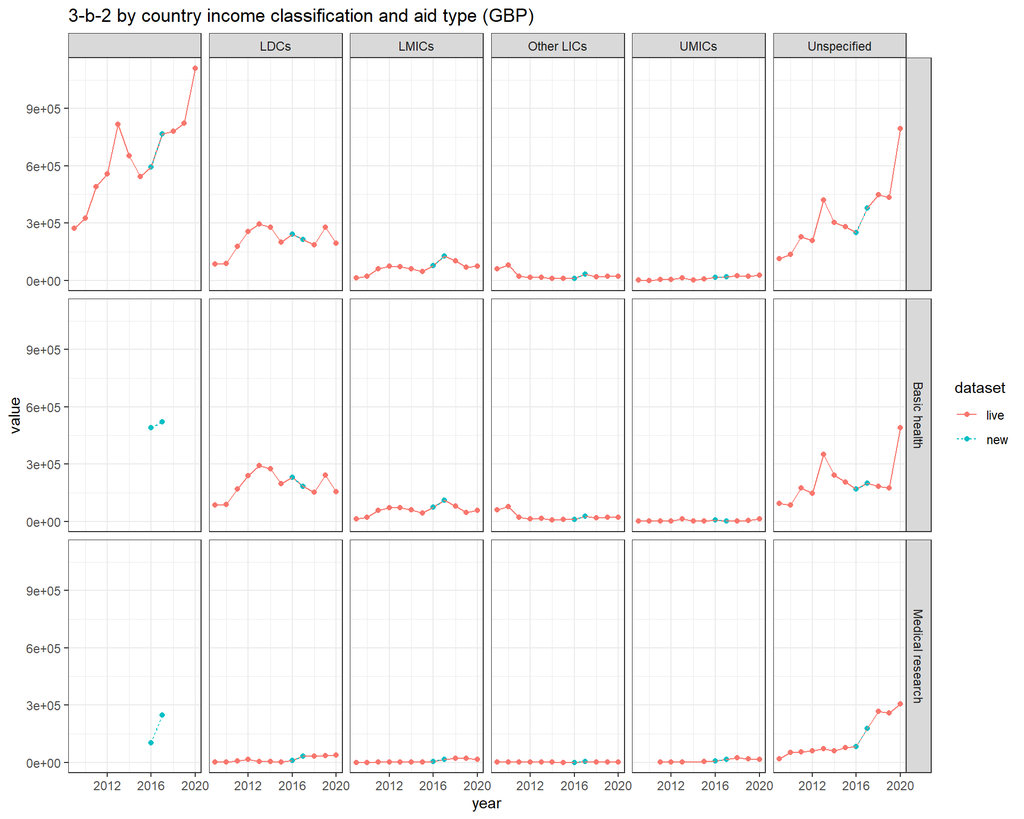

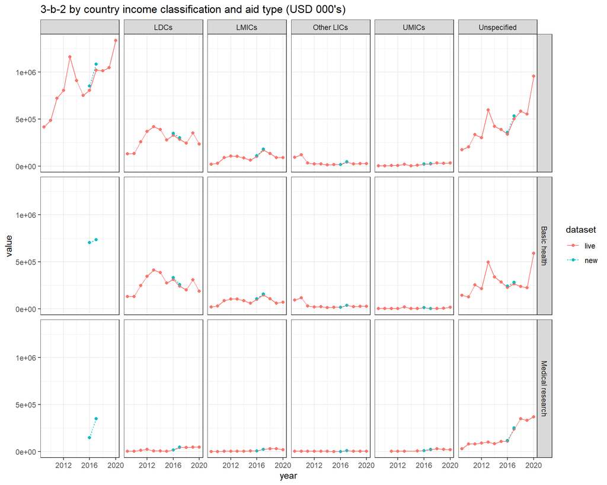

| year | country_income_classification | aid_description_crs_code | units | live | new | difference |
| --- | --- | --- | --- | --- | --- | --- |
| 2017 |  |  | Constant USD, thousands | 1022654.19965984 | 1084490.21899846 | 61836.0193386197 |
| 2016 |  |  | Constant USD, thousands | 805670.966472611 | 853318.368420765 | 47647.4019481539 |
| 2017 | Unspecified |  | Constant USD, thousands | 503356.803276287 | 533792.879350331 | 30436.0760740439 |
| 2016 | Unspecified |  | Constant USD, thousands | 338441.947631368 | 358457.413210642 | 20015.4655792742 |
| 2016 | LDCs |  | Constant USD, thousands | 327974.423552293 | 347370.839615642 | 19396.4160633496 |
| 2016 | LDCs | Basic health | Constant USD, thousands | 312717.644232313 | 331211.773859324 | 18494.1296270114 |
| 2017 | LDCs |  | Constant USD, thousands | 284700.037937611 | 301914.769037184 | 17214.7310995731 |
| 2017 | Unspecified | Basic health | Constant USD, thousands | 265463.223975649 | 281514.777917348 | 16051.5539416985 |
| 2017 | LDCs | Basic health | Constant USD, thousands | 242108.4920807 | 256747.874001029 | 14639.3819203288 |
| 2017 | Unspecified | Medical research | Constant USD, thousands | 237893.579300638 | 252278.101432983 | 14384.5221323454 |

[output cut: 51 more lines]

### 4-b-1

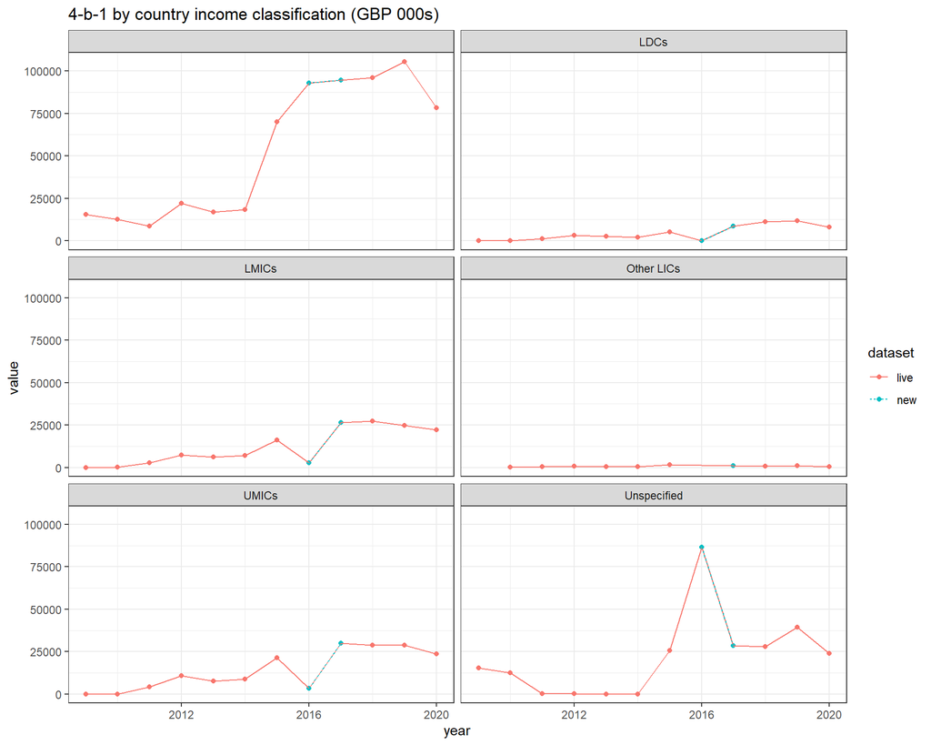

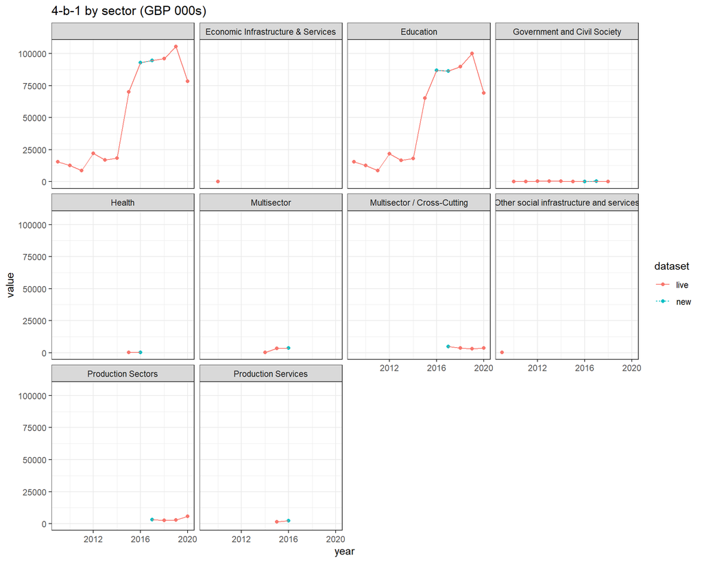

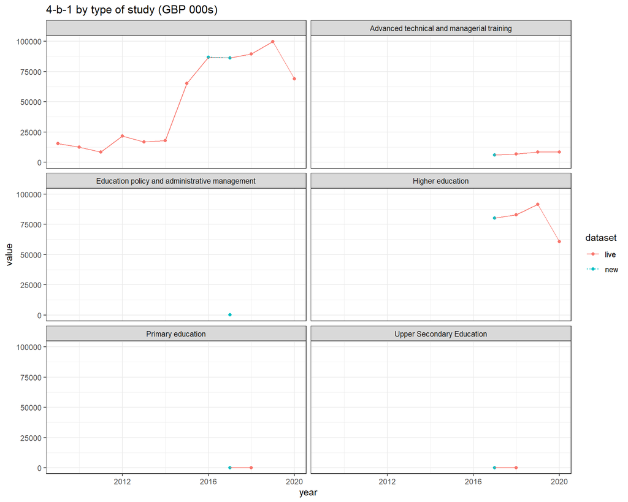

| year | sector | type_of_study | country_income_classification | units | live | new | difference |
| --- | --- | --- | --- | --- | --- | --- | --- |
| 2016 |  |  | UMICs | GBP, thousands | 3544.69 | 3544.664 | -0.0259999999998399 |
| 2016 |  |  | LMICs | GBP, thousands | 2612.1 | 2612.1177 | 0.0177000000003318 |
| 2016 | Production Services |  |  | GBP, thousands | 2260.72 | 2260.7121 | -0.00789999999960855 |
| 2016 |  |  | Unspecified | GBP, thousands | 86670.06 | 86670.0656 | 0.00560000000405125 |
| 2016 | Education |  |  | GBP, thousands | 86818.51 | 86818.515 | 0.00500000000465661 |
| 2016 |  |  |  | GBP, thousands | 92909.42 | 92909.4175 | -0.00250000000232831 |
| 2016 | Multisector |  |  | GBP, thousands | 3584.76 | 3584.7623 | 0.00229999999965003 |
| 2016 | Health |  |  | GBP, thousands | 66.07 | 66.0679 | -0.00209999999999866 |
| 2016 |  |  | LDCs | GBP, thousands | 82.57 | 82.5702 | 0.000200000000006639 |
| 2016 | Government and Civil Society |  |  | GBP, thousands | 179.36 | 179.3602 | 0.000199999999978218 |

[output cut: 1 more lines]

### 6-a-1

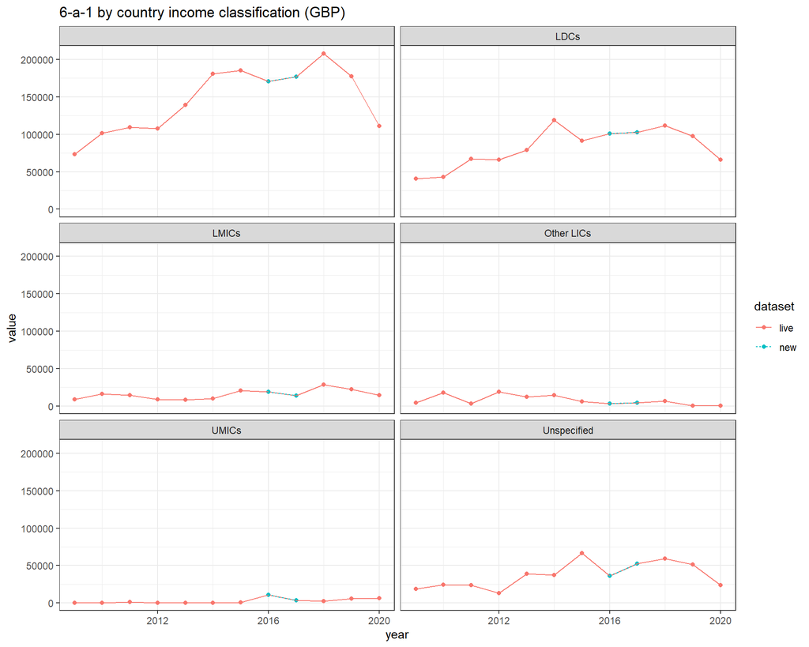

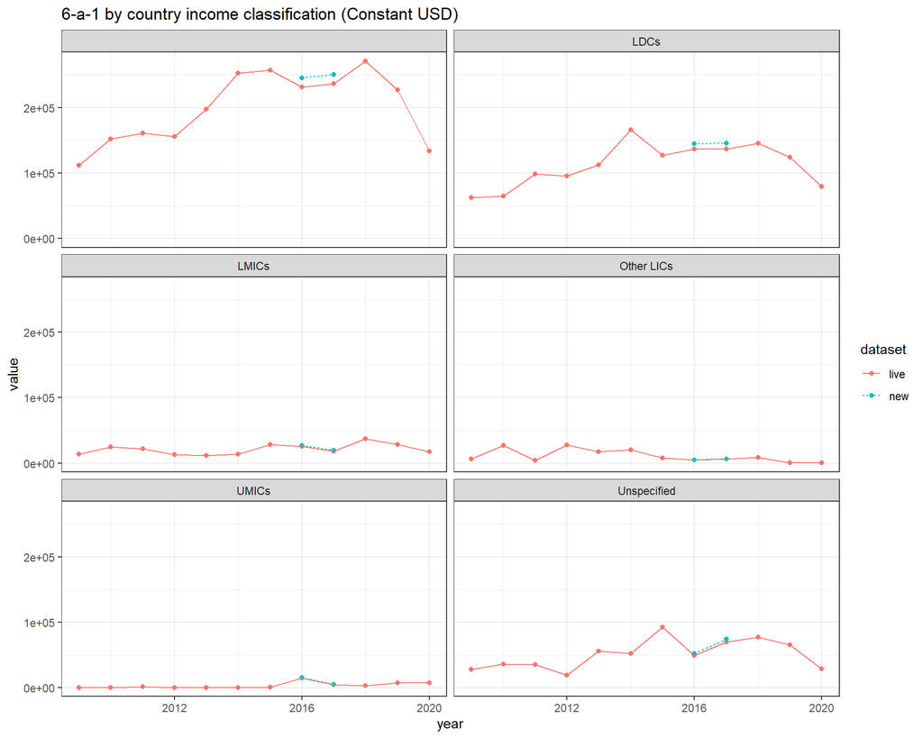

| year | country_income_classification | units | live | new | difference |
| --- | --- | --- | --- | --- | --- |
| 2017 |  | Constant USD, thousands | 236104.23341911 | 250380.560596058 | 14276.327176948 |
| 2016 |  | Constant USD, thousands | 231620.389674125 | 245318.372304505 | 13697.98263038 |
| 2017 | LDCs | Constant USD, thousands | 136870.411927566 | 145146.446428197 | 8276.03450063095 |
| 2016 | LDCs | Constant USD, thousands | 136954.534209902 | 145053.995634676 | 8099.46142477475 |
| 2017 | Unspecified | Constant USD, thousands | 69915.4003161153 | 74142.9193028179 | 4227.51898670262 |
| 2016 | Unspecified | Constant USD, thousands | 49463.0525223456 | 52388.327232985 | 2925.27471063934 |
| 2016 | LMICs | Constant USD, thousands | 25672.7397700079 | 27190.9971458828 | 1518.25737587488 |
| 2017 | LMICs | Constant USD, thousands | 18331.8288603915 | 19440.2849976358 | 1108.45613724427 |
| 2016 | UMICs | Constant USD, thousands | 14726.1781971549 | 15597.0713437251 | 870.893146570186 |
| 2017 | Other LICs | Constant USD, thousands | 6199.01328156911 | 6573.84409463984 | 374.830813070733 |

[output cut: 10 more lines]

### 7-a-1

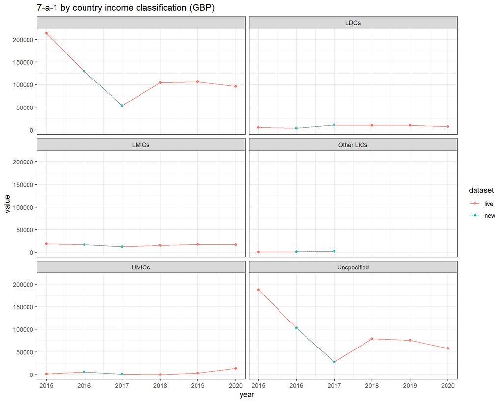

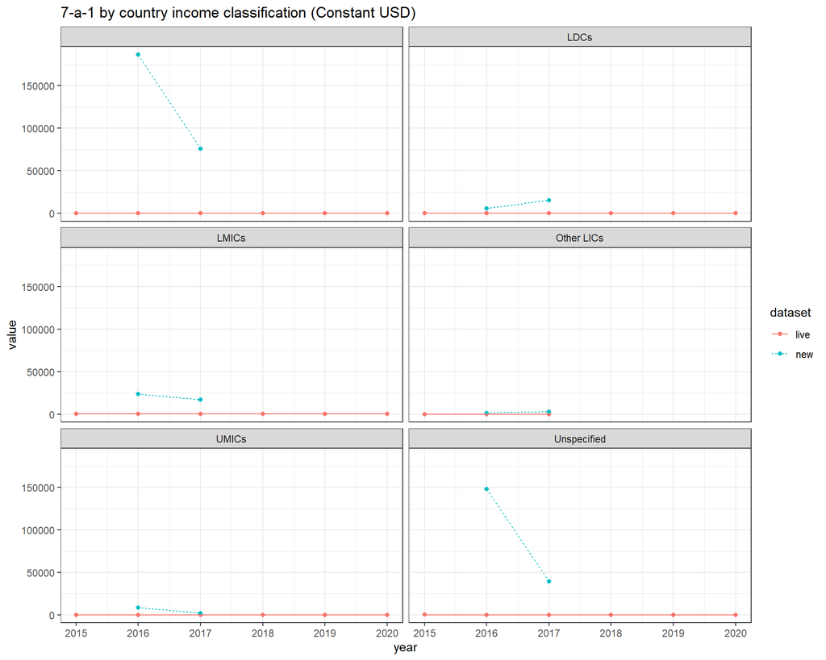

| year | country_income_classification | units | live | new | difference |
| --- | --- | --- | --- | --- | --- |
| 2016 |  | Constant USD, thousands | 173.368506623256 | 186715.409902846 | 186542.041396223 |
| 2016 | Unspecified | Constant USD, thousands | 137.27689513146 | 147845.258572205 | 147707.981677073 |
| 2017 |  | Constant USD, thousands | 71.7960365811108 | 75948.2286697172 | 75876.432633136 |
| 2017 | Unspecified | Constant USD, thousands | 37.1975714649504 | 39348.8247837744 | 39311.6272123095 |
| 2016 | LMICs | Constant USD, thousands | 21.863908511676 | 23547.1178191449 | 23525.2539106332 |
| 2017 | LMICs | Constant USD, thousands | 15.956692013178 | 16879.518028457 | 16863.5613364438 |
| 2017 | LDCs | Constant USD, thousands | 14.4273797518788 | 15261.7607975459 | 15247.333417794 |
| 2016 | UMICs | Constant USD, thousands | 8.027627419476 | 8645.6405308238 | 8637.61290340433 |
| 2016 | LDCs | Constant USD, thousands | 5.110609277844 | 5504.05332978906 | 5498.94272051122 |
| 2017 | Other LICs | Constant USD, thousands | 2.3971796346204 | 2535.81612124467 | 2533.41894161005 |

[output cut: 10 more lines]

### 8-a-1

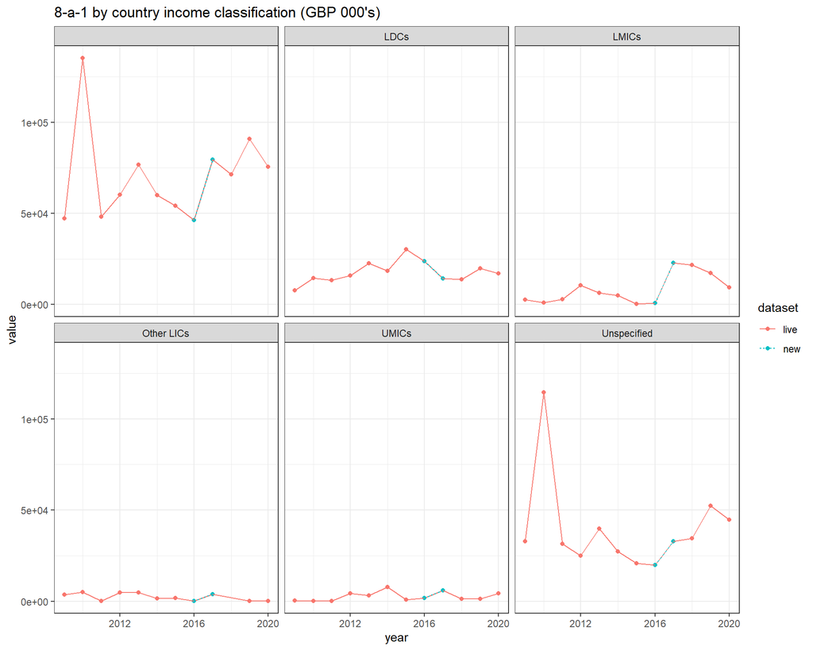

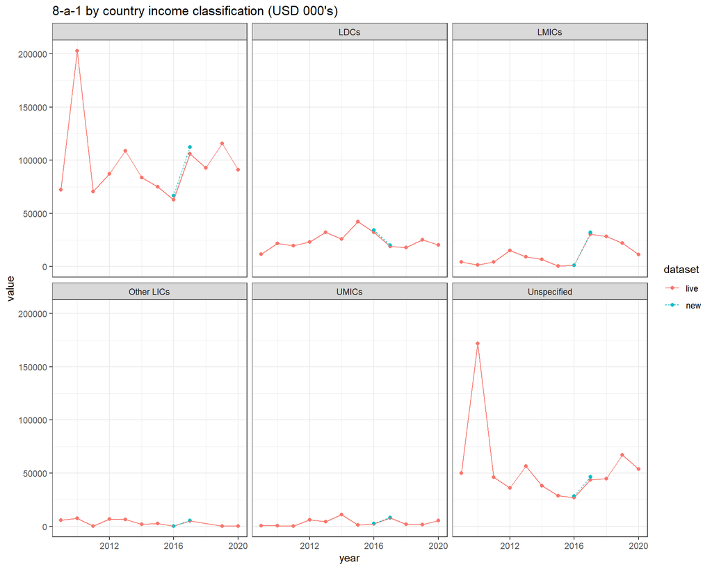

| year | country_income_classification | units | live | new | difference |
| --- | --- | --- | --- | --- | --- |
| 2017 |  | Constant USD ($ thousands) | 106008.338712068 | 112418.260741089 | 6409.92202902072 |
| 2016 |  | Constant USD ($ thousands) | 62978.3565084174 | 66702.8986507888 | 3724.54214237144 |
| 2017 | Unspecified | Constant USD ($ thousands) | 43826.3404857597 | 46476.3530106617 | 2650.012524902 |
| 2016 | LDCs | Constant USD ($ thousands) | 32291.3111036595 | 34201.0197837706 | 1909.70868011116 |
| 2017 | LMICs | Constant USD ($ thousands) | 30409.0362984704 | 32247.7553466038 | 1838.7190481334 |
| 2016 | Unspecified | Constant USD ($ thousands) | 26856.2807013121 | 28444.5619155871 | 1588.28121427499 |
| 2017 | LDCs | Constant USD ($ thousands) | 18877.2021712518 | 20018.6349633687 | 1141.43279211686 |
| 2017 | UMICs | Constant USD ($ thousands) | 7788.13656864336 | 8259.05563749097 | 470.919068847608 |
| 2017 | Other LICs | Constant USD ($ thousands) | 5107.62318794276 | 5416.46178296362 | 308.838595020868 |
| 2016 | UMICs | Constant USD ($ thousands) | 2452.88546565626 | 2597.9497881348 | 145.064322478537 |

[output cut: 8 more lines]

### 9-a-1

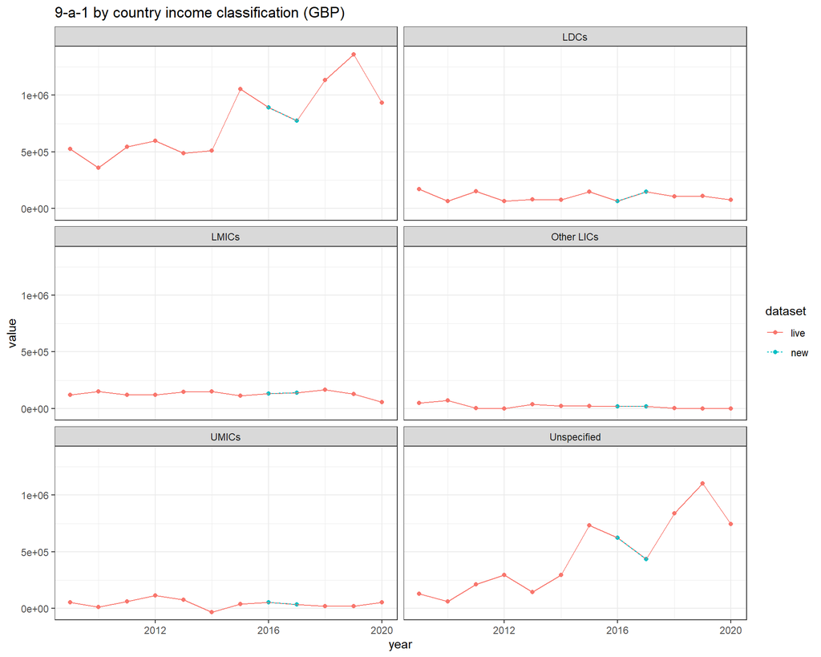

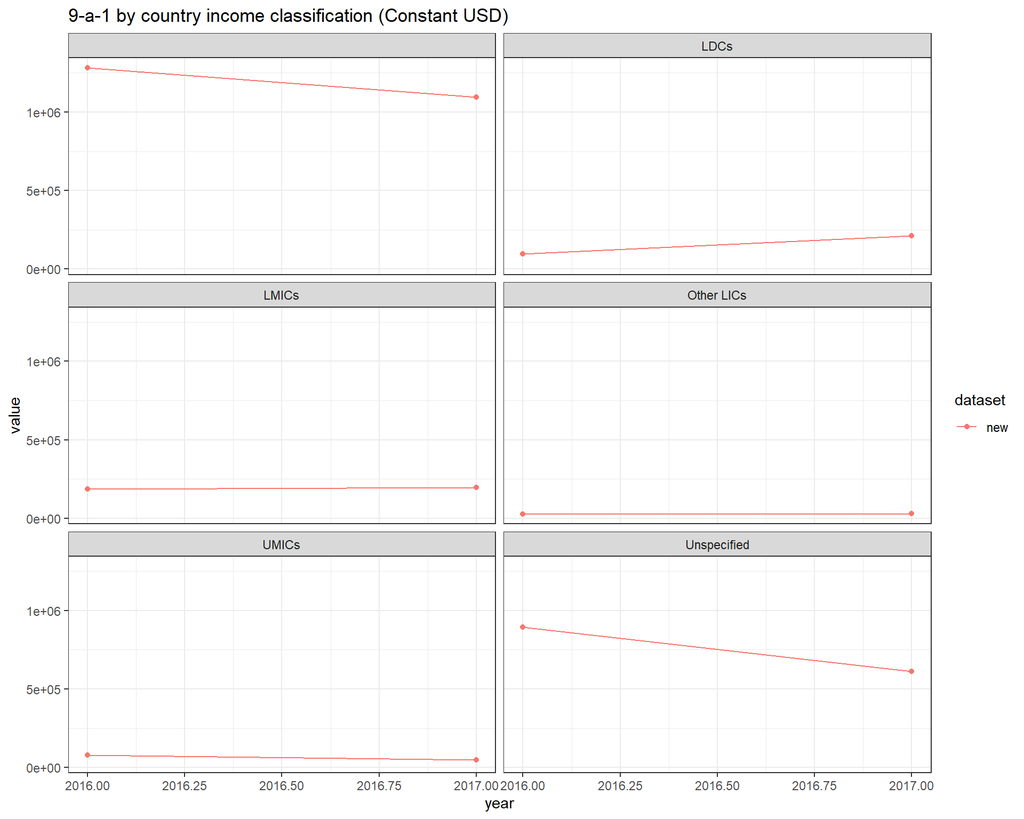

| year | country_income_classification | units | live | new | difference |
| --- | --- | --- | --- | --- | --- |
| 2016 |  | GBP, thousands | 892434.1006 | 892434.1018 | 0.00120000005699694 |
| 2016 | LMICs | GBP, thousands | 130169.20029 | 130169.2008 | 0.000510000012582168 |
| 2016 | UMICs | GBP, thousands | 53490.06899 | 53490.0695 | 0.000509999998030253 |
| 2016 | Unspecified | GBP, thousands | 622466.58266 | 622466.5831 | 0.000440000090748072 |
| 2016 | LDCs | GBP, thousands | 67188.4796 | 67188.4794 | -0.00020000000949949 |
| 2016 | Other LICs | GBP, thousands | 19119.76906 | 19119.769 | -5.99999984842725e-05 |
| 2017 |  | GBP, thousands | 775148.591072 | 775148.5910615 | -1.04999635368586e-05 |
| 2017 | LMICs | GBP, thousands | 138192.301782 | 138192.301778 | -4.00000135414302e-06 |
| 2017 | Unspecified | GBP, thousands | 434146.891602 | 434146.8915989 | -3.09996539726853e-06 |
| 2017 | LDCs | GBP, thousands | 149255.752597 | 149255.7525947 | -2.30001751333475e-06 |

[output cut: 2 more lines]

### 17-9-1

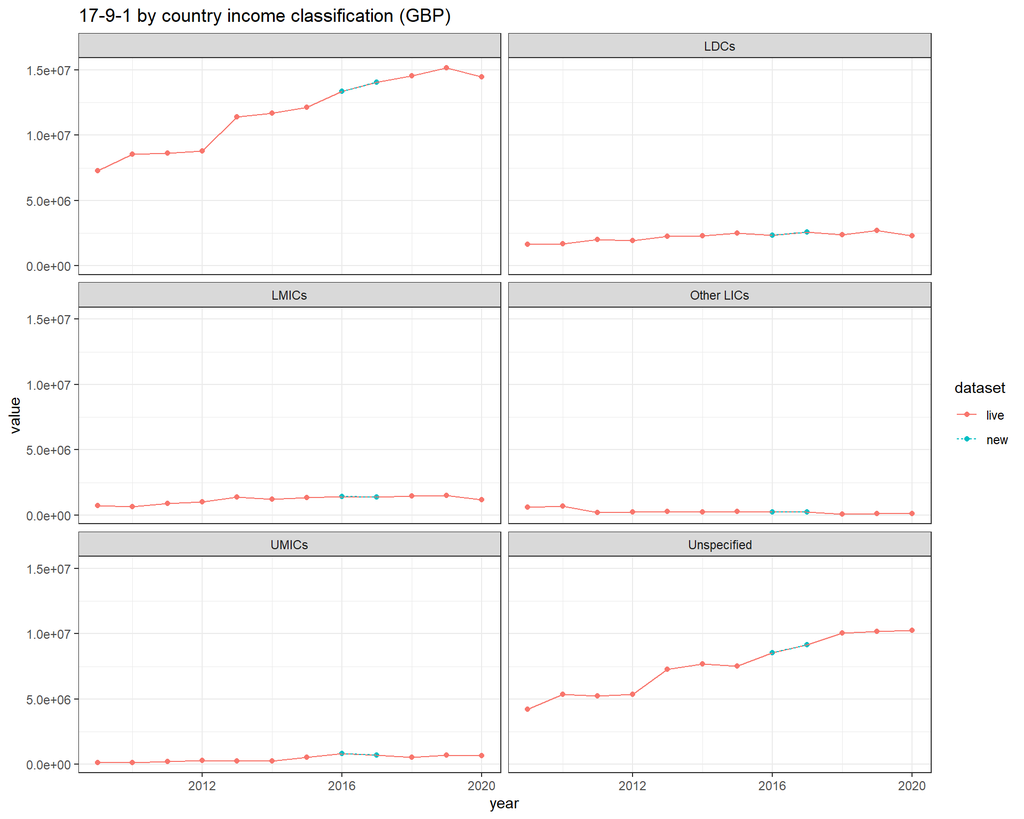

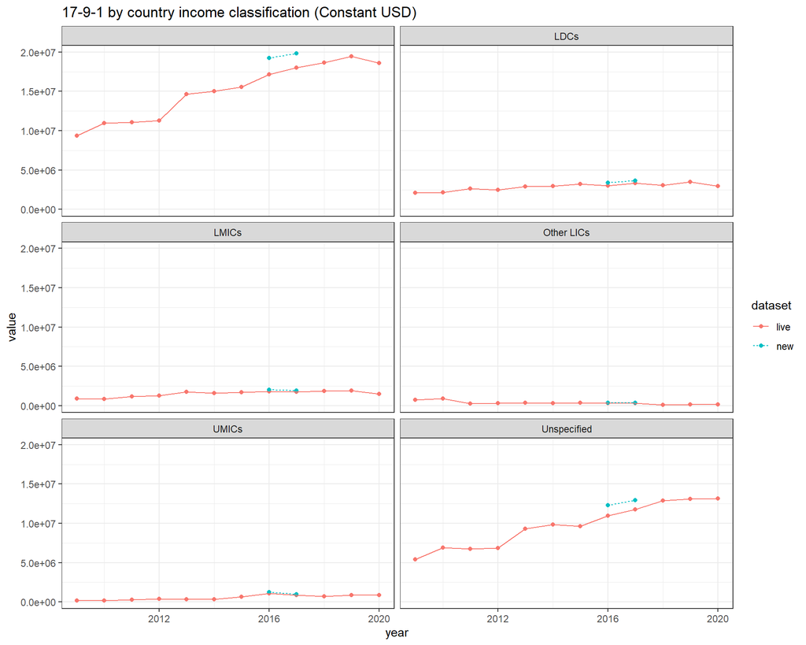

| year | country_income_classification | units | live | new | difference |
| --- | --- | --- | --- | --- | --- |
| 2016 |  | Constant USD, thousands | 17165534.9976873 | 19241962.1817239 | 2076427.18403666 |
| 2017 |  | Constant USD, thousands | 18030606.687098 | 19852242.8188602 | 1821636.13176215 |
| 2016 | Unspecified | Constant USD, thousands | 10955385.4258537 | 12280602.4931884 | 1325217.06733465 |
| 2017 | Unspecified | Constant USD, thousands | 11767925.8247172 | 12956841.9411107 | 1188916.11639357 |
| 2016 | LDCs | Constant USD, thousands | 3019767.55819365 | 3385053.43364314 | 365285.875449493 |
| 2017 | LDCs | Constant USD, thousands | 3306687.63358183 | 3640763.00742581 | 334075.37384398 |
| 2016 | LMICs | Constant USD, thousands | 1802105.23402206 | 2020096.71317661 | 217991.479154551 |
| 2017 | LMICs | Constant USD, thousands | 1746320.10362109 | 1922751.20508879 | 176431.1014677 |
| 2016 | UMICs | Constant USD, thousands | 1082663.94906959 | 1213628.28567985 | 130964.336610256 |
| 2017 | UMICs | Constant USD, thousands | 890525.07223079 | 980495.014788217 | 89969.9425574268 |

[output cut: 14 more lines]

### 17-19-1

[figure not shown]

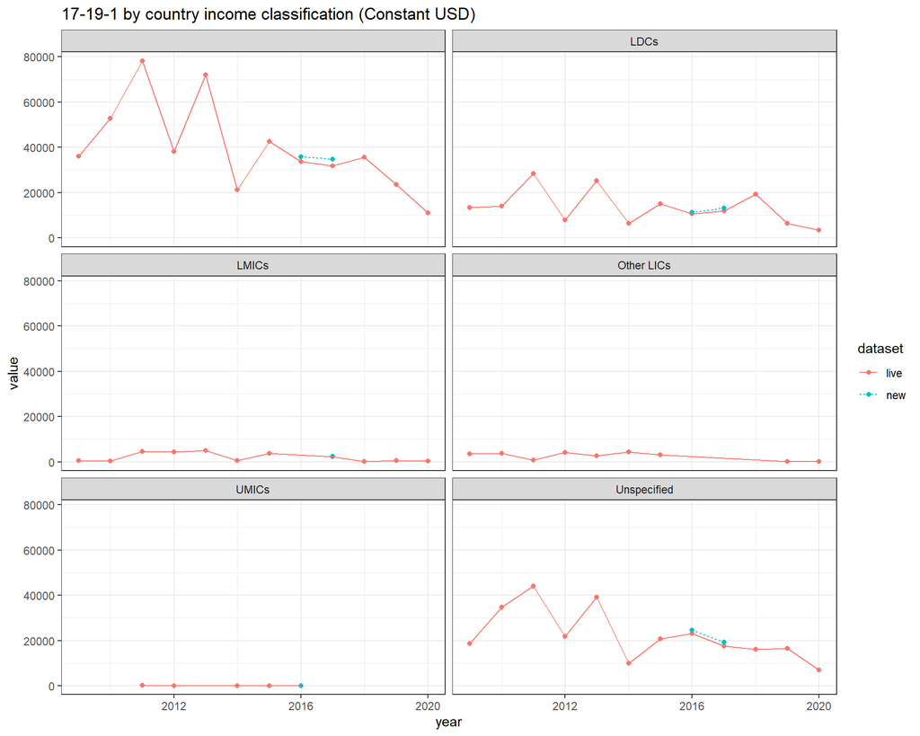

| year | country_income_classification | units | live | new | difference |
| --- | --- | --- | --- | --- | --- |
| 2017 |  | Constant USD, thousands | 31795.452374202 | 34850.2325587342 | 3054.78018453224 |
| 2016 |  | Constant USD, thousands | 33635.20354975 | 35705.9942791074 | 2070.7907293574 |
| 2017 | Unspecified | Constant USD, thousands | 17520.95178468 | 19204.2949152778 | 1683.3431305978 |
| 2016 | Unspecified | Constant USD, thousands | 23056.6986719 | 24476.2112305673 | 1419.51255866728 |
| 2017 | LDCs | Constant USD, thousands | 11951.776773926 | 13100.0557924232 | 1148.27901849722 |
| 2016 | LDCs | Constant USD, thousands | 10572.2575826 | 11223.1510593548 | 650.893476754765 |
| 2017 | LMICs | Constant USD, thousands | 2322.723815596 | 2545.88185103322 | 223.15803543722 |
| 2016 | UMICs | Constant USD, thousands | 6.24729525 | 6.63198918536687 | 0.384693935366874 |
| 2016 |  | GBP, thousands | 24823.02845 | 24823.0286 | 0.00014999999984866 |
| 2016 | LDCs | GBP, thousands | 7802.40412 | 7802.4042 | 7.99999997980194e-05 |

[output cut: 4 more lines]

## Session Info

**R version 4.0.2 (2020-06-22)**

**Platform:** x86_64-w64-mingw32/x64 (64-bit)

**locale:** *LC_COLLATE=English_United Kingdom.1252*, *LC_CTYPE=English_United Kingdom.1252*, *LC_MONETARY=English_United Kingdom.1252*, *LC_NUMERIC=C* and *LC_TIME=English_United Kingdom.1252*

**attached base packages:** *stats*, *graphics*, *grDevices*, *utils*, *datasets*, *methods* and *base*

**other attached packages:** *pander(v.0.6.5)*, *DT(v.0.20)*, *ggplot2(v.3.3.5)*, *SDGupdater(v.0.0.0.9000)*, *rsdmx(v.0.6)*, *dplyr(v.1.0.8)*, *tidyr(v.1.2.0)*, *tidyxl(v.1.0.7)*, *unpivotr(v.0.6.2)* and *stringr(v.1.4.0)*

**loaded via a namespace (and not attached):** *tinytex(v.0.37)*, *tidyselect(v.1.1.2)*, *xfun(v.0.29)*, *bslib(v.0.3.1)*, *janitor(v.2.1.0)*, *purrr(v.0.3.4)*, *snakecase(v.0.11.0)*, *colorspace(v.2.0-2)*, *vctrs(v.0.3.8)*, *generics(v.0.1.2)*, *htmltools(v.0.5.2)*, *yaml(v.2.2.2)*, *utf8(v.1.2.2)*, *XML(v.3.99-0.9)*, *rlang(v.1.0.1)*, *pillar(v.1.7.0)*, *jquerylib(v.0.1.4)*, *withr(v.2.4.3)*, *glue(v.1.6.1)*, *DBI(v.1.1.2)*, *lifecycle(v.1.0.1)*, *plyr(v.1.8.7)*, *munsell(v.0.5.0)*, *gtable(v.0.3.0)*, *zip(v.2.2.0)*, *htmlwidgets(v.1.5.4)*, *evaluate(v.0.15)*, *labeling(v.0.4.2)*, *knitr(v.1.37)*, *fastmap(v.1.1.0)*, *crosstalk(v.1.2.0)*, *curl(v.4.3.2)*, *fansi(v.1.0.2)*, *highr(v.0.9)*, *Rcpp(v.1.0.8)*, *scales(v.1.1.1)*, *jsonlite(v.1.7.3)*, *farver(v.2.1.0)*, *digest(v.0.6.29)*, *stringi(v.1.7.6)*, *openxlsx(v.4.2.5)*, *grid(v.4.0.2)*, *cli(v.3.1.1)*, *tools(v.4.0.2)*, *magrittr(v.2.0.2)*, *sass(v.0.4.0)*, *tibble(v.3.1.6)*, *crayon(v.1.5.0)*, *pkgconfig(v.2.0.3)*, *ellipsis(v.0.3.2)*, *lubridate(v.1.8.0)*, *assertthat(v.0.2.1)*, *rmarkdown(v.2.11)*, *httr(v.1.4.2)*, *rstudioapi(v.0.13)*, *R6(v.2.5.1)* and *compiler(v.4.0.2)*